# Untitled

K. Scott Alberts

June 24, 2016

Reproducable Research, Course Project #1 - Step Counting

### Setup

First, install key packages, and download and import the raw data file.

```r
#Project 1 - Movement devices
#load packages
library(dplyr)
```

```r
library(ggplot2)

#download file from webpage and upzip- only do this the first time
#URL<- "https://d396qusza40orc.cloudfront.net/repdata%2Fdata%2Factivity.zip"
#download.file(URL, destfile="activity.zip")
#unzip("activity.zip")

#input
raw <- read.csv("activity.csv", na.strings = "NA") #raw file, pre-processing.
```

### Process the data for the project.

```r
#processing
Activity <- raw #file for processing
Activity$date <- as.Date(Activity$date, "%Y-%m-%d") #convert to a Date
```

## What is the mean total number of steps taken per day?

1. Calculate the total number of steps taken per day
2. Make a histogram of the total number of steps taken each day
3. Calculate and report the mean and median of the total number of steps taken per day

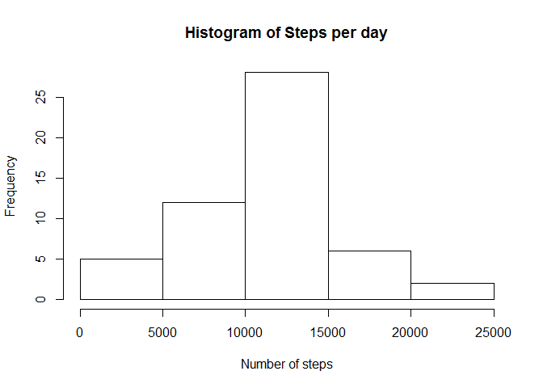

```r
#mean total steps per day
DateSum <- Activity %>% group_by(date) %>% summarize(steps=sum(steps))
hist(DateSum$steps, main="Histogram of Steps per day", xlab="Number of steps")
```

```r
MeanSteps <- mean(DateSum$steps, na.rm=TRUE)
MedianSteps<- median(DateSum$steps, na.rm=TRUE)
MeanSteps
```

```
## [1] 10766.19
```

```r
MedianSteps
```

```
## [1] 10765
```

#### The **Mean** number of steps taken per day is **10766.19 steps**.

#### The **Median** number of steps taken per day is **10765 steps**.

### What is the average daily activity pattern?

1. Make a time series plot (i.e. type = “l”) of the 5-minute interval (x-axis) and the average number of steps taken, averaged across all days (y-axis)
2. Which 5-minute interval, on average across all the days in the dataset, contains the maximum number of steps?

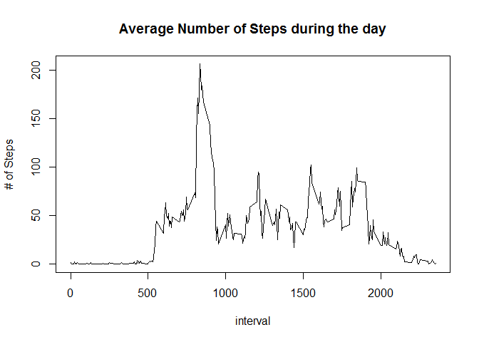

```r
#daily pattern
ActivityOmit <- na.exclude(Activity)
TimeMean <- ActivityOmit %>% group_by(interval) %>% summarise(steps=mean(steps))
MeanTime <- mean(TimeMean$steps)
plot(TimeMean$interval, TimeMean$steps, type = "l",
     main= "Average Number of Steps during the day",
     xlab="interval", ylab="# of Steps")
```

```r
TimeMean[which.max(TimeMean$steps),]
```

```
## Source: local data frame [1 x 2]
##
##   interval    steps
##      (int)    (dbl)
## 1      835 206.1698
```